# NYSE: NRT

2020-09-12

# North European Oil Royalty Trust

NRT is a trust, and it is unlike most companies listed on the New York Stock Exchange, though it has a fairly predictable cash flow. NRT generates income mainly by collecting royalties from operating companies that extract natural gas from wells that NRT owns. NRT has no debt, and its natural gas wells have remaining reserve levels that are closely monitored each year. Additionally, NRT has a finite life: when its reserves are depleted, it will likely be dissolved.

## Parameters

```r
# individualized risk-free rate
discount <- 0.0065;

# federal income bracket: $39,376 - $434,500
# net investment income tax: > $200,000
# state tax
# local tax
tax <- 0.15 + 0.038 + 0.088 + 0.039;

# number of simulation rounds
B <- 10000;
```

## Input data

We can glean the following input data from the annual and quarterly reports from the company.

```r
# net reserves at the start of 2020
# (with royalty rates factored in)
reserves.2020 <- 6429.7;

# net sales in 2016, 2017, 2018, 2019 in terms of commodity quantity
# (with royalty rates factored in)
sales.past <- c(1392, 1330, 1066, 1215);

# according to 10-Q for 2020 Q1, Q2, and Q3, sales quantities are down about 10%
sales.current <- sales.past[4] * (1 - 0.1);

# dividend per share in 2016, 2017, 2018, 2019
dividends.past <- c(0.67, 0.76, 0.70, 0.82);

# dividend per share in 2020 Q1, Q2, Q3, and Q4(E)
dividend.2020.q4 <- 0.08;
dividend.current <- 0.08 + 0.11 + 0.11 + dividend.2020.q4;

# net reserve for the start of 2021
reserves.current <- reserves.2020 - sales.current;

dividends <- c(dividends.past, dividend.current);
sales <- c(sales.past, sales.current);

# number of data points
n <- length(sales);
```

Here is where we make our judgement calls. Given the relative stability and predictability of this trust, we can probably expect its future dividends to be similar to the past.

We must specify how probable we will observe each historical data point. We believe that there is some chance that next year may be similar to current year, though we think we will most likely see sales and dividends similar to fiscal year 2019.

```r
# probability of sampling each historical data point
probs <- c(0.1, 0.1, 0.1, 0.5, 0.2);
probs <- probs / sum(probs);
```

## Functions

```r
# Project one year of dividend and remaining reserves.
# @param reserves  initial reserves
project <- function(reserves) {
    # sample one data point from historical data of (dividends, sales)
    i <- sample.int(n, 1, prob=probs);

    if (sales[i] < reserves) {
      # sufficient reserves remaining
        list(
            dividend = dividends[i],
            reserves = reserves - sales[i]
        )
    } else {
        list(
            # dividend must be discounted due to insufficient reserves
            dividend = dividends[i] * (reserves / sales[i]),
            # reserves are completely depleted
            reserves = 0
        )
    }
}

# Calculate present value of future cash flow
# @param cf  future cash flow
# @param r   discount rate
present_value <- function(cf, r) {
    n <- length(cf);
    cf / (1 + r)^(1:n)
}
```

## Analysis

Based on the parameters and the input data, we are now ready to estimate discounted future cash flows.

```r
# simulate a list of payouts
payouts.l <- lapply(
    1:B,
    function(b) {
        r <- reserves.current;
        payouts <- NULL;
        while (r > 0) {
            p <- project(r);
            payouts <- c(payouts, p$dividend);
            r <- p$reserves;
        }

        payouts
    }
);

# years remaining
years <- unlist(lapply(payouts.l, length));
table(years)
```

```
## years
##    4    5
##   41 9959
```

```r
# total discounted cash flow
dcfs <- unlist(lapply(
    payouts.l,
    function(payouts) {
        sum(present_value(payouts * (1 - tax), discount)) +
            dividend.2020.q4 * (1 - tax)
    }
));

# total discounted cash flow under no tax scenario
dcfs.no.tax <- unlist(lapply(
    payouts.l,
    function(payouts) {
        sum(present_value(payouts, discount)) +
            dividend.2020.q4
    }
));
```

From our estimates of discounted cash flows, we can now determine our profitability. By specifying our target probability of generating a profit, we can identify our entry prices for the stock.

```r
profit.prob <- 0.95;
# entry price given target probability of profit
quantile(dcfs, 1 - profit.prob)
```

```
##       5%
## 1.771074
```

```r
quantile(dcfs.no.tax, 1 - profit.prob)
```

```
##      5%
## 2.58551
```

Alternatively, we can determine whether the current price is attractive, by calculating the expected margin for the present value of profit given the current price.

```r
price <- 3.03;
mean(dcfs / price) - 1
```

```
## [1] -0.2951159
```

```r
mean(dcfs.no.tax / price) - 1
```

```
## [1] 0.02902782
```

We can also determine the probability of profit given the current price.

```r
mean(dcfs > price)
```

```
## [1] 0
```

```r
mean(dcfs.no.tax > price)
```

```
## [1] 0.6178
```

If we were to profit, our expected margin for the present value of profit is

```r
mean(dcfs.no.tax[dcfs.no.tax > price]) / price - 1
```

```
## [1] 0.09269938
```

Let us visualize the distributions of discounted cash flows.

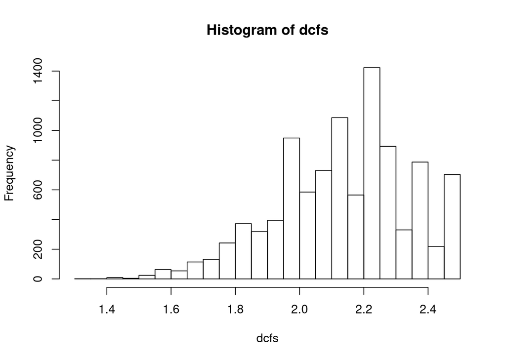

```r
hist(dcfs, breaks=20)
abline(v = price, col="red")
```

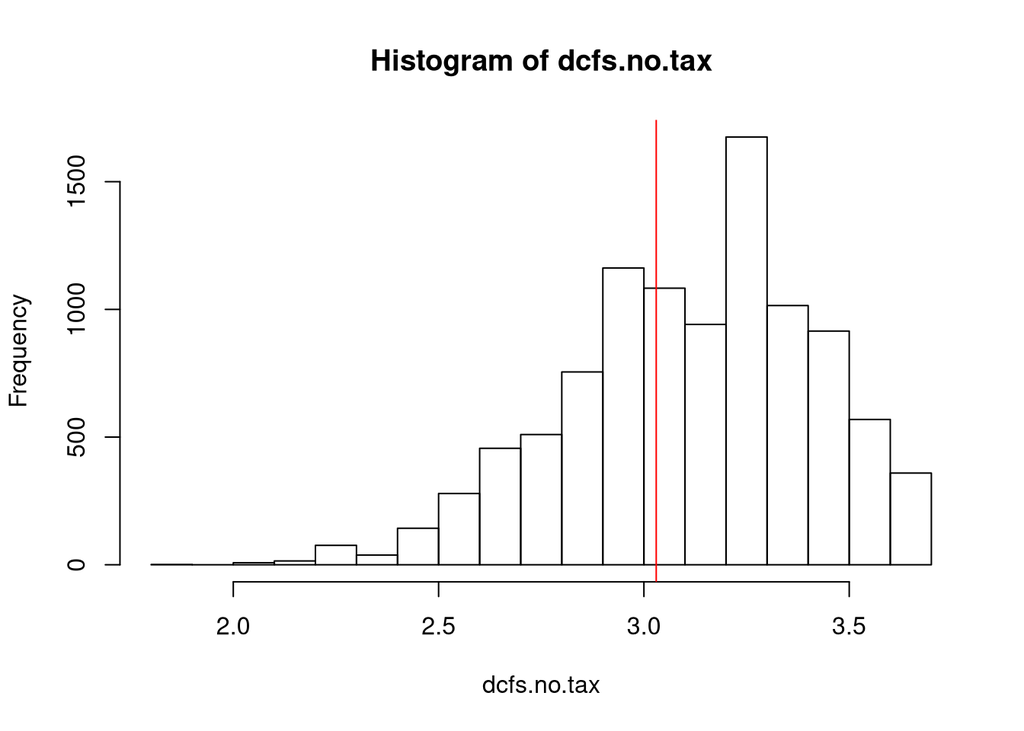

```r
hist(dcfs.no.tax, breaks=20)
abline(v = price, col="red")
```